# Администрирование локальных сетей

Лабораторная работа №5. Конфигурирование VLAN

Илья Колонтырский

Российский университет дружбы народов, Москва, Россия

09 марта 2026

# Цели и задачи работы

## Цель лабораторной работы

Получить основные навыки по настройке VLAN на коммутаторах сети, выполнить сегментацию сети и проверить связность узлов внутри отдельных VLAN.

## Задачи

- Настроить trunk-порты на коммутаторах.
- Настроить VTP Server и VTP Client.
- Создать и распространить VLAN по сети.
- Назначить access-порты соответствующим VLAN.
- Настроить статические IP-адреса на серверах и ПК.
- Проверить связность с помощью ping.
- Изучить прохождение ICMP-пакета в Simulation Mode.

# Архитектура сети

## Схема сети

- Центральный коммутатор: **msk-donskaya-irkolontirskiy-sw-1**
- Подключены:
  - коммутаторы доступа и распределения
  - серверный сегмент
  - пользовательские рабочие станции
- Обмен VLAN между коммутаторами организован через trunk-соединения

## Схема сети

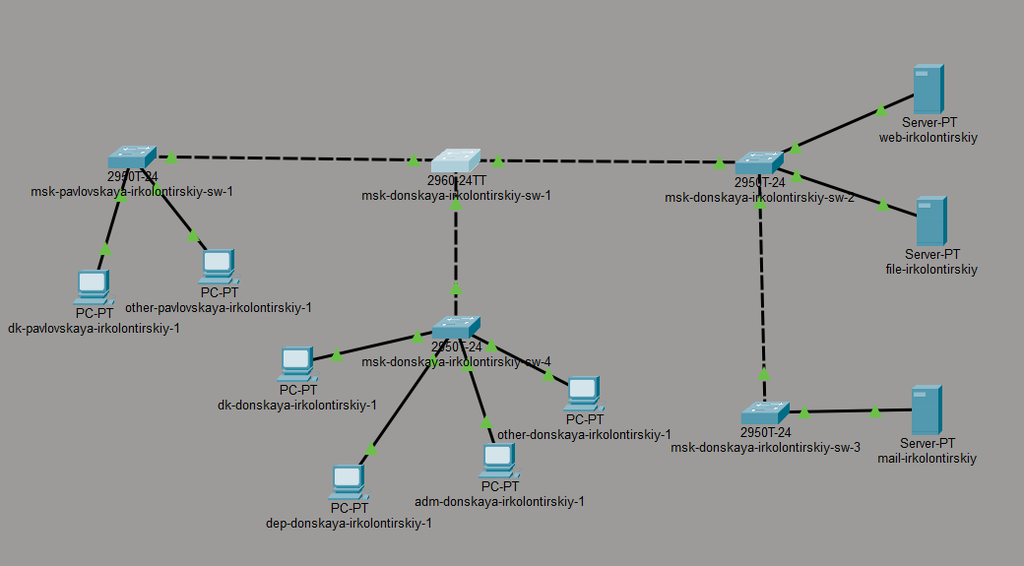

Физическая структура сети и соединения между устройствами

# Настройка VLAN и VTP

## VTP-сервер и VLAN

На коммутаторе **msk-donskaya-irkolontirskiy-sw-1** настроен режим **VTP Server**:

- домен: **donskaya**
- пароль: **cisco**

Созданы VLAN:

- **VLAN 2** — management
- **VLAN 3** — servers
- **VLAN 101** — dk
- **VLAN 102** — departaments
- **VLAN 103** — adm
- **VLAN 104** — other

## Настройка VTP-сервера

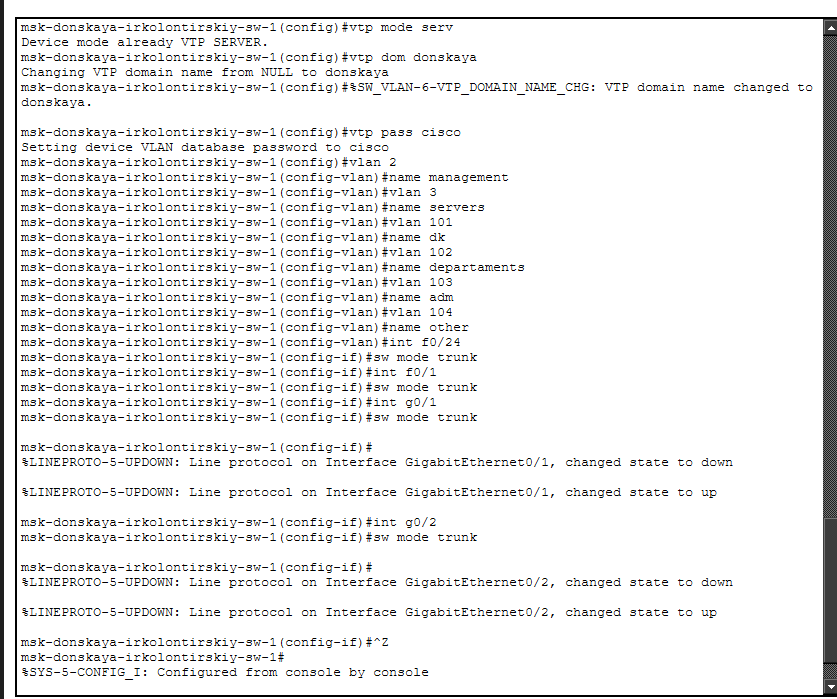

Настройка VTP Server и создание VLAN

## VTP-клиенты и назначение портов

На коммутаторах **msk-pavlovskaya-irkolontirskiy-sw-1**, **msk-donskaya-irkolontirskiy-sw-2**, **msk-donskaya-irkolontirskiy-sw-3** и **msk-donskaya-irkolontirskiy-sw-4** был настроен режим **VTP Client**.

На access-портах выполнено распределение устройств по VLAN:

- **VLAN 3** — серверы
- **VLAN 101** — dk
- **VLAN 102** — departaments
- **VLAN 103** — adm
- **VLAN 104** — other

## Назначение пользовательских VLAN

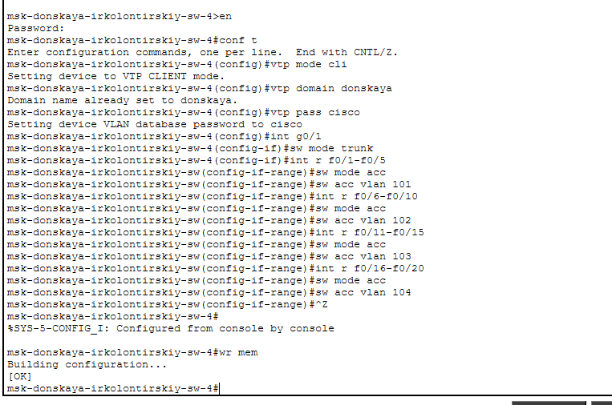

Настройка VTP Client и распределение портов по VLAN

# IP-адресация

## Настройка IP-адресов серверов

Серверы размещены в сети **10.128.0.0/24**:

- **web-irkolontirskiy** — 10.128.0.2
- **file-irkolontirskiy** — 10.128.0.3
- **mail-irkolontirskiy** — 10.128.0.4
- шлюз по умолчанию: **10.128.0.1**

## Пример настройки IP-адреса сервера

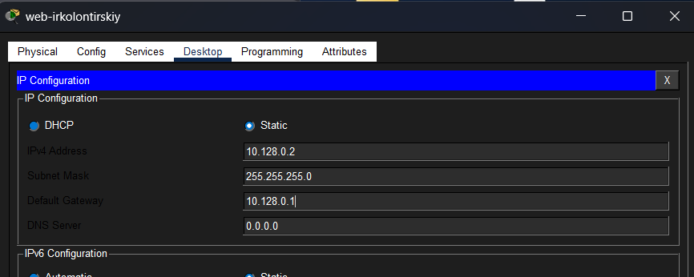

Настройка IP-адреса сервера

## Настройка IP-адресов рабочих станций

Для рабочих станций были заданы статические адреса в соответствии с VLAN:

- **VLAN 101** → сеть **10.128.3.0/24**
- **VLAN 102** → сеть **10.128.4.0/24**
- **VLAN 103** → сеть **10.128.5.0/24**
- **VLAN 104** → сеть **10.128.6.0/24**

Шлюзом в каждой подсети является адрес **.1**.

## Пример настройки IP-адреса ПК

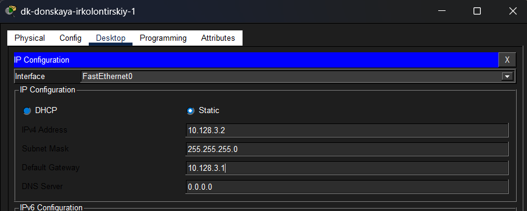

Настройка IP-адреса пользовательского ПК

# Проверка работы сети

## Результаты ping-проверки

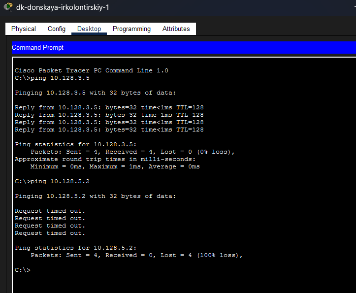

Проверка доступности устройств внутри VLAN и недоступности между VLAN

# Анализ ICMP в режиме Simulation

## Передвижение ICMP-пакета по сети

В режиме **Simulation** Packet Tracer была выполнена пошаговая трассировка ICMP-пакета между узлами одного VLAN.

При анализе установлено:

- кадр передаётся через коммутаторы по MAC-адресам
- на канальном уровне используется **Ethernet 802.1Q**
- на сетевом уровне используется **IPv4**
- для диагностики применяется протокол **ICMP**

## Simulation Mode

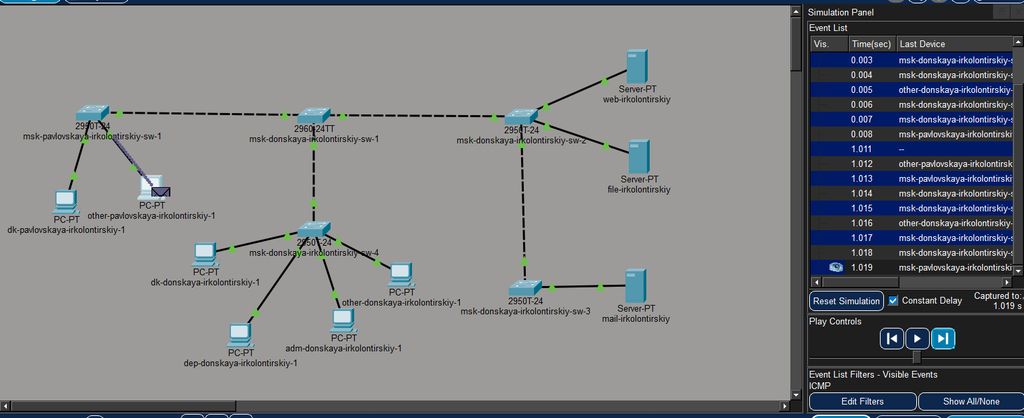

Передвижение ICMP-пакета в режиме Simulation

## Заголовки Ethernet, IP и ICMP

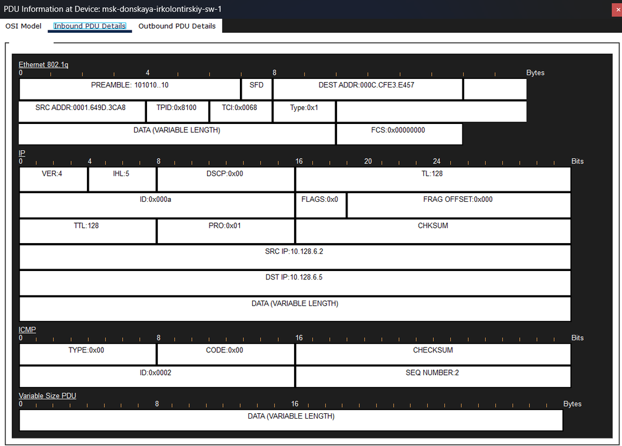

Структура ICMP-пакета и заголовков протоколов

# Выводы

## Вывод

В ходе работы была выполнена настройка коммутационной инфраструктуры сети с использованием технологий **VLAN**, **VTP** и **Trunk**.

Результаты работы:

- выполнена логическая сегментация сети;
- настроен **VTP Server** и VTP-клиенты;
- trunk-порты обеспечили передачу нескольких VLAN между коммутаторами;
- серверам и рабочим станциям назначены статические IP-адреса;
- проверена связность внутри одного VLAN;
- подтверждена изоляция устройств разных VLAN;
- изучен состав и прохождение ICMP-пакета в Packet Tracer.

В результате была получена корректно функционирующая модель локальной сети с сегментацией по VLAN и проверенной работоспособностью.